# Exploratory Analysis for INFO 478

Team members: Darren Ma, Toan Vo, Jasmeen Kaur, Jaskaran Johal

5/16/2021

Here is some important information before exploring the graphs set forth below.

- Material hearing impairment is when you see a workers average dB above 25 decibels (dB).

#### Left Ear at 2000 hz analysis

- Mean of Left Ear hearing threshold value for 2000 hz frequency is 15.2749802
- Median of Left Ear hearing threshold value for 2000 hz frequency is 10
- Max of Left Ear hearing threshold value for 2000 hz frequency is 110
- Min of Left Ear hearing threshold value for 2000 hz frequency is 1
- Standard Deviation of Left Ear hearing threshold value for 2000 hz frequency is 11.7707615
- Range of Left Ear hearing threshold value for 2000 hz frequency is 1, 110

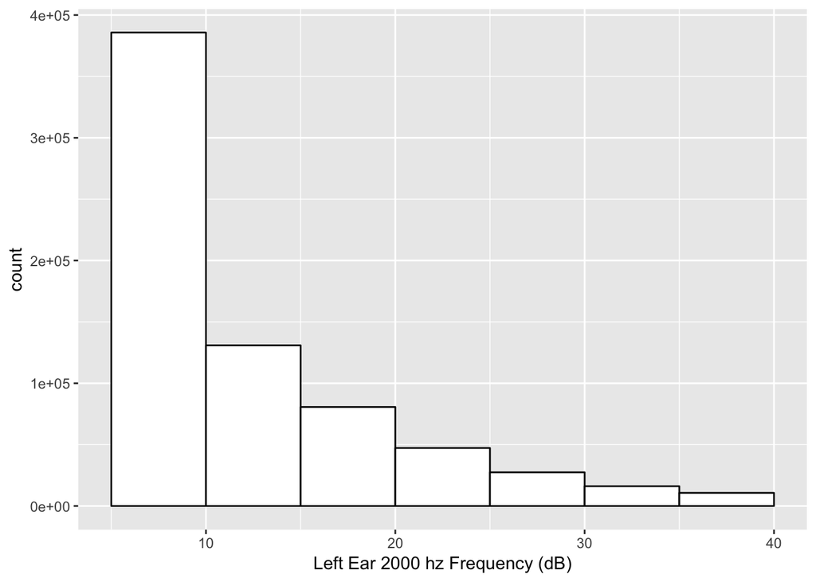

Graph showing the distribution of Left ear hearing threshold value for 2000 Hz frequency Each interval of 5 represents the hearing level in decibels (dB), less meaning it’s better. Each bucket represents the total number of people who had a hearing level of dB at 2000 hz frequency. For left ear, it is very good that most of our data is in the first ‘bucket’ of 10 dB or less. This means that at 2000 hz frequency, most workers had not developed material hearing loss. We see approximately 15%-20% of workers develop material hearing loss because of their average being over 25 dB.

#### Right Ear at 2000 hz analysis

- Mean of Right Ear hearing threshold value for 2000 hz frequency is 14.0612923
- Median of Right Ear hearing threshold value for 2000 hz frequency is 10
- Max of Right Ear hearing threshold value for 2000 hz frequency is 100
- Min of Right Ear hearing threshold value for 2000 hz frequency is 5
- Standard Deviation of Right Ear hearing threshold value for 2000 hz frequency is 11.1953263
- Range of Right Ear hearing threshold value for 2000 hz frequency is 5, 100

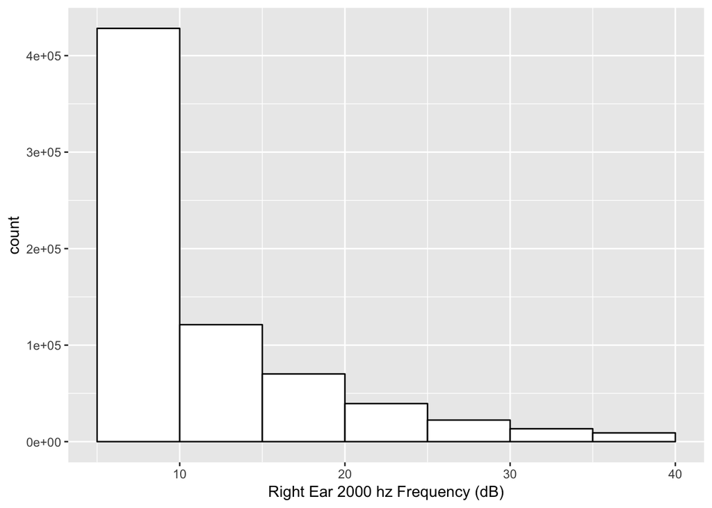

Graph showing the distribution of Right ear hearing threshold value for 2000 Hz frequency. Each interval of 5 represents the hearing level in decibels (dB), less meaning it’s better. Each bucket represents the total number of people who had a hearing level at 2000 hz frequency. As we can see with the right ear as well, it is very good that most of our data is in the first ‘bucket’ of 10 dB or less. This means that most workers did not develop material hearing loss. but around 15%-20% (like left ear) did develop material hearing loss because they averaged above 25 decibels.

To compare both graphs, the left ear has a mean of 15 decibels while the right ear has a mean of 14 decibels. So, similar averages. The standard deviations are very similar as well, both around 11. This means that 68% of the data is within 1 standard deviation or 11 decibels, to the left and right. Then 95% of the data is withing 2 standard deviations.

### Top 10 Jobs with high Decibel Averages

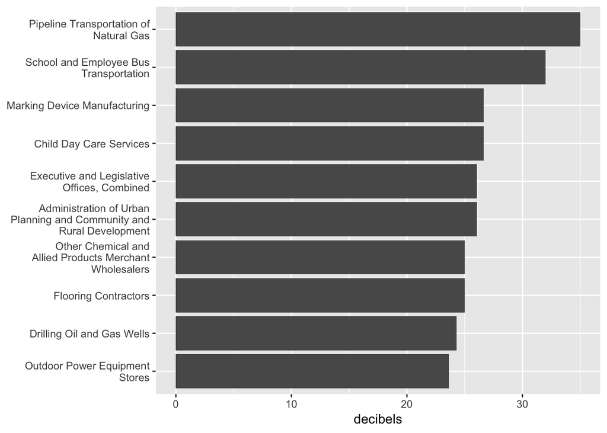

### Left Ear 6000 hz frequency vs Right Ear 6000 hz frequency

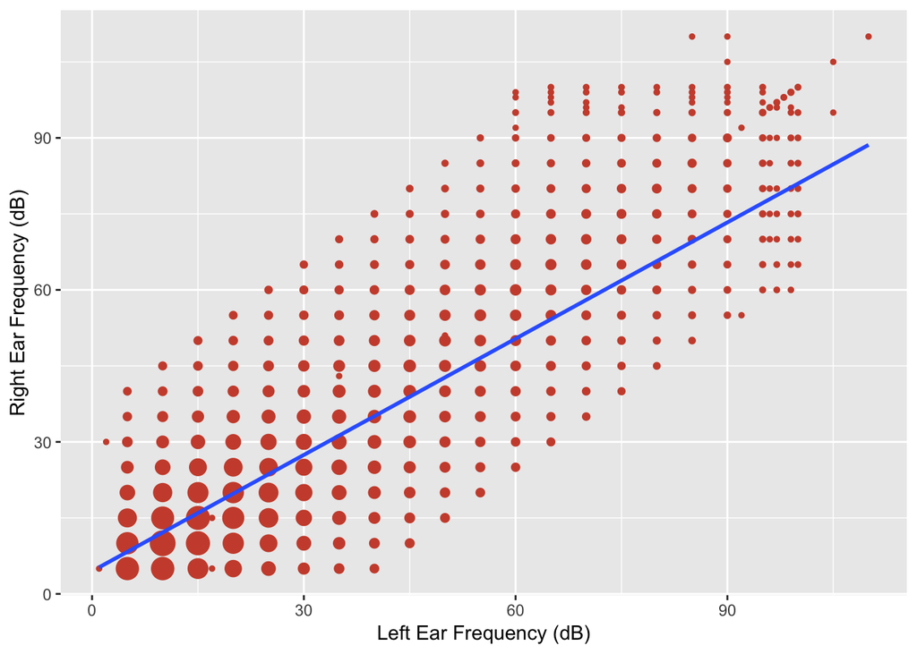